# Aufgabenblatt 6

## Statistik für Wirtschaftsinformatiker, Übung, HTW Berlin

### Martin Spott, Michael Heimann, Shirin Riazy

Stand: 13.05.2024

## Wiederholung

- Was sind Varianz, Standardabweichung und Variationskoeffizient? Wie werden sie berechnet?
- Welche Fragestellung ist Gegenstand der Konzentrationsmessung einer Werteverteilung?
- Was wird mit einer Lorenzkurve dargestellt?
- Was ist der Gini-Koeffizient?

## Aufgabe 6.1 (Streuungsmaße)

Berechne die mittlere absolute Abweichung vom arithmetischen Mittel, die Varianz und die Standardabwei-chung für das Merkmal *Schluss* aus dem Datensatz `bmw.csv` von Aufgabenblatt 5.

1. Berechne die drei Maße händisch in R
2. Benutze die R-Funktionen `var()` und `sd()` für Varianz und Standardabweichung.

```r
bmw <- read.csv2("C:/Users/rafaa/Desktop/HTW MODULE/Semester 3/Statistik/data/bmw.csv")

schluss <- as.numeric(bmw$Schluss)

# a)
# Mittlere absolute Abweichung vom arithmetischen Mittel
mean(abs(schluss - mean(schluss)))
```

```
[1] 0.6299308
```

```r
# Varianz
mean((schluss - mean(schluss))^2)
```

```
[1] 0.5956978
```

```r
# Standardabweichung
sqrt(mean((schluss - mean(schluss))^2))
```

```
[1] 0.7718146
```

```r
# b)
# Mittlere absolute Abweichung vom arithmetischen Mittel
mean(abs(schluss - mean(schluss)))
```

```
[1] 0.6299308
```

```r
# Varianz
var(schluss)
```

```
[1] 0.6045888
```

```r
# Standardabweichung
sd(schluss)
```

```
[1] 0.7775531
```

**Beachte:** In R wird – wie bei den meisten anderen Statistikprogrammen – nicht die **empirische Varianz** (population variance) sondern die **Stichprobenvarianz** (sample variance) berechnet. Siehe in den Unterlagen zur Vorlesung nach, um den Unterschied herauszufinden.

## Aufgabe 6.2 (Variationskoeffizient)

Der Aktienkurs der Volkswagenaktie wies in einem Zeitraum von 250 Handelstagen bei einem Mittelwert von 174,56€ eine Standardabweichung von 10,28€ auf. Für den gleichen Zeitraum ermittelt man für die Aktie der BMW AG eine Standardabweichung 4,68€ bei einem Mittelwert von 36,96€.

Berechne die Variationskoeffizienten für die Volkswagenaktie und für die BMW-Aktie. Was sagen uns die Werte? Vergleiche die Variationskoeffizienten der beiden Aktien.

```r
# Variationskoeffizient Volkswagen
10.28 / 174.56 * 100
```

```
[1] 5.889093
```

```r
# Variationskoeffizient BMW AG
4.68 / 36.96 * 100
```

```
[1] 12.66234
```

```r
# 5,89% und 12,66%.

#Ein niedrigerer Variationskoeffizient deutet auf eine geringere Streuung im Verhältnis zum Mittelwert hin, während ein höherer Wert auf eine größere Streuung hindeutet.
#In diesem Fall hat die BMW-Aktie einen höheren Variationskoeffizienten als die Volkswagenaktie, was darauf hindeutet, dass die Streuung der BMW-Aktie im Verhältnis zum Mittelwert größer ist als die Streuung der Volkswagenaktie.
#Dies könnte darauf hinweisen, dass die BMW-Aktie volatiler ist oder größere Schwankungen im Preis im Vergleich zur Volkswagenaktie aufweist.
```

## Aufgabe 6.3 (Lorenzkurve)

Für das Jahr 2012 wurde folgende Statistik der Neuzulassungen für PKW veröffentlicht (Quelle: http://www.kfz-auskunft.de/kfz/pkw_neuzulassungen_hersteller_2012.html)

```r
library(knitr)
zulassungen <- read.csv("C:/Users/rafaa/Desktop/HTW MODULE/Semester 3/Statistik/data/neuzulassungen.csv")
kable(zulassungen)
```

| Hersteller | Stueckzahl |
| --- | --- |
| VW | 672921 |
| BMW | 284494 |
| Mercedes | 283006 |
| Audi | 266582 |
| Opel | 213627 |
| Ford | 206128 |
| Renault | 150740 |
| Skoda | 147197 |
| Hyundai | 100875 |
| Toyota | 83834 |

Erarbeite mit diesen Daten eine Lorenzkurve, ohne das R-Paket zu nutzen. Füge dazu die folgenden Spalten als Hilfe zu, die wir auch in der Vorlesung im Beispiel mit den Einrichtungshäusern benutzt haben:

- $i$: Index, nach aufsteigenden Einheiten sortiert
- $h_i$: absolute Häufigkeit des Herstellers, also $h_i = 1$ für alle $i$
- $f_i$: relative Häufigkeit des Herstellers
- $F_i$: kumulierte relative Häufigkeit des Herstellers
- $h_i^* = \textit{Stueckzahl}_i$: Stückzahl des Herstellers $i$
- $f_i^* = h_i^* / \sum_{j=1}^{10} h_j^*$: Einheiten jedes Herstellers relativ zur Summe aller Einheiten
- $F_i^*$ sind die $f_i^*$ kumuliert.

Welche beiden Spalten zeigt die Lorenzkurve? Zeichne die Lorenzkurve mit der Funktion `plot()`.

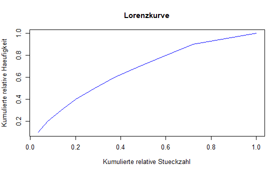

```r
# Daten laden
Stueckzahl <- zulassungen$Stueckzahl

# Sortieren der Stückzahlen
Stueckzahl_sortiert <- sort(Stueckzahl)

# Absolute Häufigkeit (h_i)
h_i <- rep(1, length(Stueckzahl_sortiert))

# Relative Häufigkeit (f_i)
f_i <- h_i / length(Stueckzahl_sortiert)

# Kumulierte relative Häufigkeit (F_i)
F_i <- cumsum(f_i)

# Stückzahl jedes Herstellers (h_i^*)
h_i_star <- Stueckzahl_sortiert

# Relative Stückzahl jedes Herstellers (f_i^*)
f_i_star <- h_i_star / sum(h_i_star)

# Kumulierte relative Stückzahl (F_i^*)
F_i_star <- cumsum(f_i_star)

# Lorenzkurve plotten
plot(F_i_star, F_i, type = "l", col = "blue", xlab = "Kumulierte relative Stueckzahl", ylab = "Kumulierte relative Haeufigkeit", main = "Lorenzkurve")
```

```r
NA
NA
```